# 04-elaboration exploration analyses

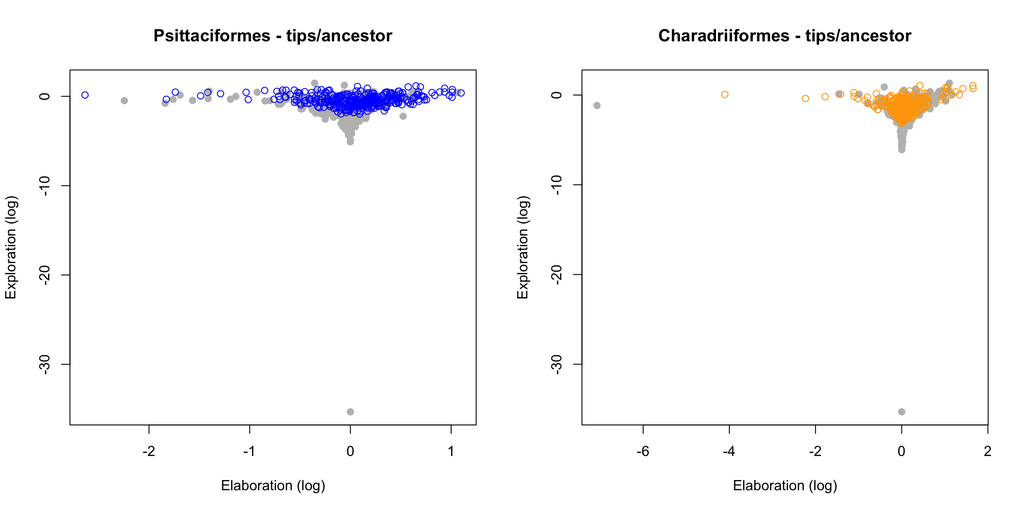

```r
## Centroid (tips) ancestor trajectory
psita_results <- project.reject(tmp_simple_matrices$psita,
                                 vector = c("tips", "ancestor"))
chara_results <- project.reject(tmp_simple_matrices$chara,
                                 vector = c("tips", "ancestor"))

par(mfrow = c(1,2))
plot.project.reject.log(psita_results, tmp_simple_matrices$psita, col = "blue", main = "Psittaciformes - tips/ancestor")
plot.project.reject.log(chara_results, tmp_simple_matrices$chara, col = "orange", main = "Charadriiformes - tips/ancestor")
```

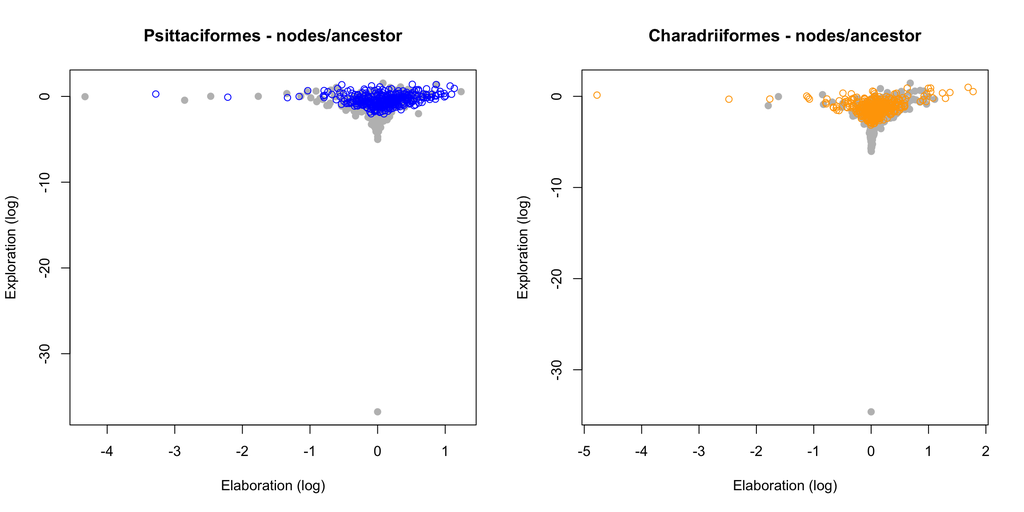

```r
## Centroid (nodes) ancestor trajectory
psita_results <- project.reject(tmp_simple_matrices$psita,
                                 vector = c("nodes", "ancestor"))
chara_results <- project.reject(tmp_simple_matrices$chara,
                                 vector = c("nodes", "ancestor"))

par(mfrow = c(1,2))
plot.project.reject.log(psita_results, tmp_simple_matrices$psita, col = "blue", main = "Psittaciformes - nodes/ancestor")
plot.project.reject.log(chara_results, tmp_simple_matrices$chara, col = "orange", main = "Charadriiformes - nodes/ancestor")
```

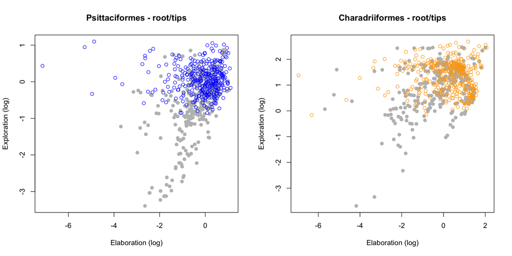

```r
## Centroid (root) tips trajectory
psita_results <- project.reject(tmp_simple_matrices$psita,
                                 vector = c("root", "tips"))
chara_results <- project.reject(tmp_simple_matrices$chara,
                                 vector = c("root", "tips"))

par(mfrow = c(1,2))
plot.project.reject.log(psita_results, tmp_simple_matrices$psita, col = "blue", main = "Psittaciformes - root/tips")
plot.project.reject.log(chara_results, tmp_simple_matrices$chara, col = "orange", main = "Charadriiformes - root/tips")
```

## Elaboration/exploration in the present

Apply these metrics on both clades to get two scores for each taxa (elaboration vs. exploration plots).

Measure the exploration/elaboration for all clades in the whole bird trees and see which ones are particularly low/high?

## Elaboration/exploration through time

Do some time-slicing and run these metrics through time.

## Annex: some potentially interesting ratio thingy

```r
## Loading the whole shape space
shapespace <- readRDS("../Data/Raw/Beak_data/2020_08_07_MMB_MORPHO_SHAPESPACE_FULL.rds")$PCscores
## Getting the vector from that space
space_vector <- apply(shapespace, 2, quantile, prob = c(0.25, 0.75))
psita_space_proj <- projections(spaces_list$psittaciformes, point1 = space_vector[1,], point2 = space_vector[2, ])
psita_space_reje <- projections(spaces_list$psittaciformes, point1 = space_vector[1,], point2 = space_vector[2, ], measure = "distance")
chara_space_proj <- projections(spaces_list$charadriiformes, point1 = space_vector[1,], point2 = space_vector[2, ])
chara_space_reje <- projections(spaces_list$charadriiformes, point1 = space_vector[1,], point2 = space_vector[2, ], measure = "distance")
## Groups
group <- list("Psittaciformes" = trees_list$psittaciformes[[1]]$tip.label,
              "Charadriiformes" = trees_list$charadriiformes[[1]]$tip.label,
              "Others" = rownames(shapespace)[!(rownames(shapespace) %in% c(trees_list$psittaciformes[[1]]$tip.label, trees_list$charadriiformes[[1]]$tip.label))])
## Full space plot
plot(custom.subsets(shapespace, group = group), col = c("blue", "orange", "grey"), pch = c(19, 19, 21), main = "Bird beak shape space")
arrows(x0 = space_vector[1,1], y0 = space_vector[1,2],
       x1 = space_vector[2,1], y1 = space_vector[2,2], col = "black", lwd = 4)
```

[output not shown]

```r
par(mfrow = c(2, 2))
## The elaboration/exploration profiles
plot(psita_space_proj, psita_space_reje, pch = 19, col = "blue",
    xlab = "Elaboration", ylab = "Exploration", main = "Psitta explo/elaboration profile (total)")
plot(chara_space_proj, chara_space_reje, pch = 19, col = "orange",
    xlab = "Elaboration", ylab = "Exploration", main = "Chara explo/elaboration profile (total)")

## The elaboration/exploration profiles
plot(abs(psita_space_proj), psita_space_reje, pch = 19, col = "blue",
    xlab = "Elaboration (absolute)", ylab = "Exploration", main = "Psitta explo/elaboration profile (total)")
plot(abs(chara_space_proj), chara_space_reje, pch = 19, col = "orange",
    xlab = "Elaboration (absolute)", ylab = "Exploration", main = "Chara explo/elaboration profile (total)")
```

[output not shown]

Meh… But we can also do ratios: the one between the within group elaboration/exploration and the total elaboration/exploration. This can help us find the big time explorers/elaborators? (here: the one in the top 99% CI)

```r
## Get the ratio
reje_ratio <- psita_reje/psita_space_reje
proj_ratio <- abs(psita_proj)/abs(psita_space_proj)

## Find the 99% top explorers/elaborators
top_explo <- which(reje_ratio >= quantile(reje_ratio, prob = 0.99))
top_elab <- which(proj_ratio >= quantile(proj_ratio, prob = 0.99))
top_explo_names <- rownames(spaces_list$psittaciformes)[top_explo]
top_elab_names <- rownames(spaces_list$psittaciformes)[top_elab]

plot(proj_ratio, reje_ratio, pch = 19, col = "blue",
    xlab = "Group/space elaboration", ylab = "Group/space exploration", main = "Psittaciformes")
text(cbind(proj_ratio, reje_ratio)[top_explo, ], labels = top_explo_names, pos = 4)
text(cbind(proj_ratio, reje_ratio)[top_elab, ], labels = top_elab_names, pos = 1)
```

[output not shown]

```r
## Get the ratio
reje_ratio <- chara_reje/chara_space_reje
proj_ratio <- abs(chara_proj)/abs(chara_space_proj)

## Find the 99% top explorers/elaborators
top_explo <- which(reje_ratio >= quantile(reje_ratio, prob = 0.99))
top_elab <- which(proj_ratio >= quantile(proj_ratio, prob = 0.99))
top_explo_names <- rownames(spaces_list$charadriiformes)[top_explo]
top_elab_names <- rownames(spaces_list$charadriiformes)[top_elab]

plot(proj_ratio, reje_ratio, pch = 19, col = "orange",
    xlab = "Group/space elaboration", ylab = "Group/space exploration", main = "Charadriiformes")
text(cbind(proj_ratio, reje_ratio)[top_explo, ], labels = top_explo_names, pos = 4)
text(cbind(proj_ratio, reje_ratio)[top_elab, ], labels = top_elab_names, pos = 1)
```

[output not shown]

Maybe it’s picking up some weird birds…